# GroupMe Data Download

Jordan Farrer

2017-02-22

# 1 Executive Summary

# 2 Data Acquisition

```r
pacman::p_load(tidyverse, forcats, pander, stringr, jsonlite, lubridate, RcppRoll, jrfTools, googlesheets)
```

GroupMe uses a token (which created at dev.groupme.com/session/new) to access the API. My API token stored in the file `.groupme_api_token` and loaded into `token`. Below we first download information about each group my account has access to:

```r
base_url <- "https://api.groupme.com/v3/"
token <- paste0("?token=", system("cat .groupme_api_token", intern = TRUE))

i <- 1; more_response <- TRUE; groups <- tibble();
while (more_response) {
    url <- paste0(base_url,"groups", token, "&per_page=10&page=", i)
    tmp_df <- fromJSON(url, flatten = TRUE)$response %>% as_tibble()
    if (nrow(tmp_df) == 0) {
      more_response <- FALSE
    } else {
      groups <- bind_rows(groups, tmp_df)
      i <- i + 1
    }
}
```

Current GroupMe groups that I am in

| id | group_id | name | type |
| --- | --- | --- | --- |
| 19105351 | 19105351 | Wharton - 2018 | private |
| 26132445 | 26132445 | HOLEKAMP (w)A(ng)BUSE | private |
| 25971303 | 25971303 | Wharton SpikeBall | private |
| 23319758 | 23319758 | WG 18 Cohort 2F | private |

Next create functions to download and save the messages from a single group. We pass it the `group_id` associated with **Wharton - 2018**. This is complicated a bit by the the fact that you are only able to down 100 messages at a time. So the json for one batch of 100 will look different from another batch of 100. In order to compensate for this, we identify a general structure of variables and create standardized data_frame’s that can be bound together.

```r
fn_message_structure <- function(tmp_list) {
  all_column <-
    lapply(tmp_list, function(x) {
      sapply(x, class) %>%
        as.data.frame() %>%
        rownames_to_column(var = 'column') %>%
        as_tibble() %>%
        setNames(c("column", "class"))
      }
    ) %>%
      bind_rows() %>%
      group_by(column, class) %>%
      count() %>%
      ungroup()

  structure <-
    all_column %>%
      group_by(column) %>%
      filter(row_number() == 1) %>%
      ungroup()

  return(structure)
}

fn_standardize_message_df <- function(df, structure) {

  # Create table of new columns to add
  new_cols <-
    structure %>%
    filter(!(column %in% names(df)))

  # Initialize an empty list
  structure_list <- list()
  if(nrow(new_cols) > 0) {
    for (i in 1:nrow(new_cols)) {
      structure_list[[new_cols$column[i]]]  <- as.formula(paste0("~as.", new_cols$class[i], "(rep(NA,", nrow(df),"))"))
    }
  }

  # From df bind new data frame of NAs and select in right order
  df %>%
    bind_cols(
      tibble_(structure_list)
    ) %>%
    select(one_of(structure$column)) %>%
    mutate_if(str_detect(names(.), "user\\.id"), as.integer)

}

fn_dl_group_messages <- function(group_id) {

  i <- 1; more_response <- TRUE; tmp_list <- list();last_id <- "";
  while(more_response) {
    before_id_param <- ifelse(last_id == "", "", paste0("&before_id=", last_id))
    url <- paste0(base_url,"groups/",group_id,"/messages", token, "&limit=100", before_id_param)
    tmp_msg <- try(
      fromJSON(url, flatten = TRUE)$response$messages %>% as_tibble()
      , silent = TRUE
    )
    if ("try-error" %in% class(tmp_msg)) {
      more_response <- FALSE
    } else {
      tmp_list[[i]] <- tmp_msg
      last_id <- tail(tmp_msg, 1)$id
      i <- i + 1
    }
  }

  structure <- fn_message_structure(tmp_list)
  tmp_list2 <- lapply(tmp_list, fn_standardize_message_df, structure)
  all_messages <- bind_rows(tmp_list2)
  saveRDS(all_messages, paste0(data_dir, group_id, ".RDS"))
  return(all_messages)
}

all_messages <- fn_dl_group_messages(group_id = "19105351")
```

The `all_messages` data frame contains columns with nested data frames and vectors.

| attachments | avatar_url | created_at | event.data.added_users | event.data.adder_user.id | event.data.adder_user.nickname | event.data.event.id | event.data.event_name | event.data.event.name | event.data.minutes | event.data.name | event.data.removed_user.id | event.data.removed_user.nickname | event.data.remover_user.id | event.data.remover_user.nickname | event.data.updated_fields | event.data.url | event.data.user.id | event.data.user.nickname | event.type | favorited_by | group_id | id | name | sender_id | sender_type | source_guid | system | text | user_id |
| --- | --- | --- | --- | --- | --- | --- | --- | --- | --- | --- | --- | --- | --- | --- | --- | --- | --- | --- | --- | --- | --- | --- | --- | --- | --- | --- | --- | --- | --- |
|  | https://i.groupme.com/748x748.jpeg.8c46fd2fc7ca4c07a919a846e2a18a06 | 1487765865 |  | NA | NA | NA | NA | NA | NA | NA | NA | NA | NA | NA |  | NA | NA | NA | NA |  | 19105351 | 148776586587301403 | Oran Barkai | 36783785 | user | 2FB198E5-D548-4343-A39D-47D7436CE822 | FALSE | Startup Nation is coming to Penn!\n\nJoin us today at 5:30pm in Hall of Flags, to explore Israeli startups and technologies at the Startup Nation Tech Fair.\nMeet innovators and entrepreneurs, and lea… | 36783785 |
|  | https://i.groupme.com/200x200.jpeg.c564ea52d81f4b109c9a9d8016d87e65 | 1487744470 |  | NA | NA | NA | NA | NA | NA | NA | NA | NA | NA | NA |  | NA | NA | NA | NA |  | 19105351 | 148774447070575354 | Sera Mijung Koo | 40255908 | user | 0428b9ddf43d1dd3e5031339c403ba44 | FALSE | Hi everyone!! \n\nDo you care about your own money? Join Common Cents TODAY 4:30PM @ JMHH 370 for guest speaker event on Personal Investment Strategy. \n\nWei Wang, Managing Partner and lead portfolio… | 40255908 |
|  | https://i.groupme.com/2080x1170.png.674686d542c14fbe99883aac08525c91 | 1487742340 |  | NA | NA | NA | NA | NA | NA | NA | NA | NA | NA | NA |  | NA | NA | NA | NA |  | 19105351 | 148774234075922207 | Anu | 38136444 | user | android-b4cac7e0-16bc-4cda-a7fd-3698e0ffc993 | FALSE | @Rickie Koo | 38136444 |
|  | https://i.groupme.com/750x750.jpeg.9796fbd35ad14700b6e67049e1c56edd | 1487741531 |  | NA | NA | NA | NA | NA | NA | NA | NA | NA | NA | NA |  | NA | NA | NA | NA |  | 19105351 | 148774153197844000 | Patrick Elyas | 4599198 | user | 6DCAFD61-E0F0-4E30-9466-4A319994A556 | FALSE | Let me know if anyone is selling a Thursday follies ticket | 4599198 |
|  | https://i.groupme.com/750x750.jpeg.384166a9d7fb4a65b6ec6fb6c4a30af5 | 1487740389 |  | NA | NA | NA | NA | NA | NA | NA | NA | NA | NA | NA |  | NA | NA | NA | NA |  | 19105351 | 148774038932725354 | Mona Kadouh | 36950480 | user | CCF024B4-3D00-4928-B257-CE55BB96E5BE | FALSE | \U0001f1f1\U0001f1e7\U0001f1f1\U0001f1e7\U0001f1f1\U0001f1e7\U0001f1f1\U0001f1e7Dear friends, spring break is around the corner and a lot of you will be booking your next trip on your long flight back… | 36950480 |
|  | https://i.groupme.com/200x200.jpeg.b9ec4a27865445ae816ec062d0e5fb91 | 1487735134 |  | NA | NA | NA | NA | NA | NA | NA | NA | NA | NA | NA |  | NA | NA | NA | NA |  | 19105351 | 148773513411975142 | Rickie Koo | 34793578 | user | f1c2adca33117b99a2cda037caa7b7ee | FALSE | Selling 2 Thursday Follies tickets (Front Orchestra, M23 and M25). DM me if interested! | 34793578 |
|  | https://i.groupme.com/750x750.jpeg.0c85ee31c6ba41ab92555d55522daede | 1487730424 |  | NA | NA | NA | NA | NA | NA | NA | NA | NA | NA | NA |  | NA | NA | NA | NA |  | 19105351 | 148773042491561015 | Anne Shen | 5329901 | user | AC202EE3-8FF2-49B6-8792-E594435F7C4E | FALSE | Two Friday Follies tickets for sale: O17, O15 @ $65 each, DM if you want them! | 5329901 |
|  | https://i.groupme.com/2080x1170.png.674686d542c14fbe99883aac08525c91 | 1487726954 |  | NA | NA | NA | NA | NA | NA | NA | NA | NA | NA | NA |  | NA | NA | NA | NA |  | 19105351 | 148772695407703322 | Anu | 38136444 | user | android-b8c3d183-50ec-438d-97a1-6481aa03459c | FALSE | Selling 1 or 2 Follies tickets for Friday. Premium Orchestra. DD1, DD2. DM if interested | 38136444 |
|  | https://i.groupme.com/750x750.jpeg.25d514fa2b244ddf8cc11c7dab5f0101 | 1487726193 |  | NA | NA | NA | NA | NA | NA | NA | NA | NA | NA | NA |  | NA | NA | NA | NA |  | 19105351 | 148772619320617236 | Angela Meng | 2555970 | user | 38DED999-C8CF-47F4-B788-B4074FE5191C | FALSE | Thank you @Ankit Agarwal WG18 who found them ! | 2555970 |
|  | https://i.groupme.com/750x750.jpeg.25d514fa2b244ddf8cc11c7dab5f0101 | 1487725200 |  | NA | NA | NA | NA | NA | NA | NA | NA | NA | NA | NA |  | NA | NA | NA | NA |  | 19105351 | 148772520088377236 | Angela Meng | 2555970 | user | 6C113680-B8CC-45CA-9469-DF4653029381 | FALSE | Looking for my keys that I've lost in huntsman -- has a Swarthmore college lanyard on it | 2555970 |

# 3 Data Processing

In order to better interact with the data, we will create “tables” (in the SQL sense):

1. Users
2. Messages
3. Likes
4. Media (pics, videos, gifs)
5. Mentions

## 3.1 Users

We unnest the members data frame from the users data frame to get the current set of users in the **Wharton - 2018** GroupMe.

```r
users_sex <- gs_title("groupme_users") %>%  gs_read(ws = "users")
```

[output not shown]

[output cut: 20 more lines]

[output not shown]

```r
users <-
  groups %>%
  filter(name == "Wharton - 2018") %>%
  select(group_id, members) %>%
  unnest() %>%
  left_join(
    users_sex %>%
      select(user_id, sex) %>%
      mutate(
        user_id = as.character(user_id)
        , sex = factor(sex, levels = c("Female","Male"))
      )
    , by = 'user_id'
  ) %>%
  arrange(user_id)
```

| group_id | user_id | nickname | image_url | id | muted | autokicked | sex |
| --- | --- | --- | --- | --- | --- | --- | --- |
| 19105351 | 10006049 | Jared Horvitz | https://i.groupme.com/748x748.jpeg.c88a057e4b5b4c94985dab3de116bc1f | 146603512 | FALSE | FALSE | Male |
| 19105351 | 100773 | Alula Selassie | https://i.groupme.com/638x640.jpeg.4f7f92c172c4456d9a4aa9bd1cea3e26 | 172611969 | FALSE | FALSE | Male |
| 19105351 | 10161622 | Anderson 辛安 | https://i.groupme.com/200x266.jpeg.fdd55c0212004739a95fee3f9b72c181 | 207780823 | TRUE | FALSE | Male |
| 19105351 | 10217059 | Kirtika Challa | https://i.groupme.com/200x200.jpeg.b391cf8c114343cbafbf62b00f6ac77d | 176580059 | TRUE | FALSE | Female |
| 19105351 | 10467730 | RJ Martin | NA | 185577371 | FALSE | FALSE | Male |
| 19105351 | 10477508 | Debbie Lam | https://i.groupme.com/1022x1024.jpeg.2323c15e63fd4d6a98266e0c3da1c9e1 | 179243589 | FALSE | FALSE | Female |
| 19105351 | 10491246 | Ari Zelman | https://i.groupme.com/750x750.jpeg.742bc3f64eb548598d2c04b14e2b27e1 | 179416273 | TRUE | FALSE | Male |
| 19105351 | 10572519 | Ravi Mulani | https://i.groupme.com/200x193.jpeg.5f9d25dc526247278c015a960128cd5b | 172765137 | FALSE | FALSE | Male |
| 19105351 | 10816880 | Clay Gregory | https://i.groupme.com/750x750.jpeg.29ed19b5bac4488f8ee87d44d73ec22d | 188204860 | TRUE | FALSE | Male |
| 19105351 | 10849198 | Frank Li | https://i.groupme.com/200x200.jpeg.397143120d5e4a8ea4ae5617858f51b1 | 146480130 | TRUE | FALSE | Male |

## 3.2 Messages

GroupMe records each event (e.g. user entering the group, creating an event, changing their nickname for the group), so we isolate only the messages sent my users create a “fact table” which is keyed on `msg_id`.

```r
msgs_from_jan <-
  all_messages %>%
  filter(system == FALSE & is.na(event.type)) %>%
  select(group_id, id, created_at, user_id, name, text) %>%
  rename(msg_id = id) %>%
  mutate(created_at = as.POSIXct(created_at, origin = "1970-01-01", tz = "America/New_York"))
```

| group_id | msg_id | created_at | user_id | name | text |
| --- | --- | --- | --- | --- | --- |
| 19105351 | 148776586587301403 | 2017-02-22 07:17:45 | 36783785 | Oran Barkai | Startup Nation is coming to Penn!\n\nJoin us today at 5:30pm in Hall of Flags, to explore Israeli startups and technologies at the Startup Nation Tech Fair.\nMeet innovators and entrepreneurs, and lea… |
| 19105351 | 148774447070575354 | 2017-02-22 01:21:10 | 40255908 | Sera Mijung Koo | Hi everyone!! \n\nDo you care about your own money? Join Common Cents TODAY 4:30PM @ JMHH 370 for guest speaker event on Personal Investment Strategy. \n\nWei Wang, Managing Partner and lead portfolio… |
| 19105351 | 148774234075922207 | 2017-02-22 00:45:40 | 38136444 | Anu | @Rickie Koo |
| 19105351 | 148774153197844000 | 2017-02-22 00:32:11 | 4599198 | Patrick Elyas | Let me know if anyone is selling a Thursday follies ticket |
| 19105351 | 148774038932725354 | 2017-02-22 00:13:09 | 36950480 | Mona Kadouh | \U0001f1f1\U0001f1e7\U0001f1f1\U0001f1e7\U0001f1f1\U0001f1e7\U0001f1f1\U0001f1e7Dear friends, spring break is around the corner and a lot of you will be booking your next trip on your long flight back… |
| 19105351 | 148773513411975142 | 2017-02-21 22:45:34 | 34793578 | Rickie Koo | Selling 2 Thursday Follies tickets (Front Orchestra, M23 and M25). DM me if interested! |
| 19105351 | 148773042491561015 | 2017-02-21 21:27:04 | 5329901 | Anne Shen | Two Friday Follies tickets for sale: O17, O15 @ $65 each, DM if you want them! |
| 19105351 | 148772695407703322 | 2017-02-21 20:29:14 | 38136444 | Anu | Selling 1 or 2 Follies tickets for Friday. Premium Orchestra. DD1, DD2. DM if interested |
| 19105351 | 148772619320617236 | 2017-02-21 20:16:33 | 2555970 | Angela Meng | Thank you @Ankit Agarwal WG18 who found them ! |
| 19105351 | 148772520088377236 | 2017-02-21 20:00:00 | 2555970 | Angela Meng | Looking for my keys that I've lost in huntsman -- has a Swarthmore college lanyard on it |

## 3.3 Likes

Each message can have many likes so it’s best to store this information as a separate table.

```r
msg_likes <-
  all_messages %>%
  filter(system == FALSE & is.na(event.type)) %>%
  rowwise() %>%
  filter(class(favorited_by) != "list") %>%
  select(id, favorited_by) %>%
  unnest() %>%
  rename(
    msg_id = id
    , liked_by = favorited_by
  )
```

| msg_id | liked_by |
| --- | --- |
| 148776586587301403 | 5525329 |
| 148774447070575354 | 3608564 |
| 148774447070575354 | 40193722 |
| 148774447070575354 | 40361901 |
| 148774038932725354 | 10217059 |
| 148774038932725354 | 22872726 |
| 148774038932725354 | 233088 |
| 148774038932725354 | 2333297 |
| 148774038932725354 | 24995007 |
| 148774038932725354 | 2918821 |

## 3.4 Media (pics, videos, gifs)

The media sent in a message is buried in another part of the json file. We unnest the the media and store individual links in a separate table.

```r
msg_media <-
  all_messages %>%
  filter(system == FALSE & is.na(event.type)) %>%
  select(id, attachments) %>%
  unnest() %>%
  filter(type %in% c("linked_image", "image","video")) %>%
  select(msg_id = id, type, url) %>%
  mutate(type = ifelse(type == "linked_image", "gif", type))
```

| msg_id | type | url |
| --- | --- | --- |
| 148761589462811363 | image | https://i.groupme.com/1688x2250.jpeg.f5a14ce3365640c3aab562166dd6aece |
| 148761511388378621 | image | https://i.groupme.com/1125x1500.jpeg.9448730fd5644dfd957128f55a7935f3 |
| 148748827534432525 | gif | https://i.groupme.com/655x438.jpeg.a08d4a06c36544bf8704f36668c29634 |
| 148747109819073683 | image | https://i.groupme.com/1136x1136.jpeg.75a62db9a4c64a7cb7839cce6677f47a |
| 148719848488583391 | image | https://i.groupme.com/1280x720.jpeg.3e3d39bf27a3444c921daef0f20e466e |
| 148718294970175458 | image | https://i.groupme.com/1125x1500.jpeg.a184fb05c1ed42b899d4e0a5f1147346 |
| 148710289812924000 | image | https://i.groupme.com/1125x1500.jpeg.b8f54c629b034b7d90bd1655f8103d7b |
| 148710289357223272 | image | https://i.groupme.com/1125x1500.jpeg.5b535921c61242bd8c5b46ccccdeee1f |
| 148708966318713683 | image | https://i.groupme.com/1125x1500.jpeg.668093fa9ea34bf9bfc6b4664a1a55fd |
| 148687961437515354 | image | https://i.groupme.com/640x387.jpeg.1d1881a567b64b09a154f7d6a495f053 |

## 3.5 Message Mentions

Within each mesage, a user can mention multiple users so we separate this into another table as well.

```r
msg_mentions <-
  all_messages %>%
  filter(system == FALSE & is.na(event.type)) %>%
  select(id, attachments) %>%
  unnest() %>%
  filter(type %in% c("mentions")) %>%
  select(msg_id = id, user_ids) %>%
  unnest()
```

| msg_id | user_ids |
| --- | --- |
| 148774234075922207 | 34793578 |
| 148772619320617236 | 36535881 |
| 148769998287222755 | 34500822 |
| 148769380770794000 | 26433687 |
| 148768973340112525 | 26433687 |
| 148768843078043272 | 26433687 |
| 148768819336438621 | 8807264 |
| 148768186110273272 | 730715 |
| 148763686095895458 | 36573091 |
| 148763686095895458 | 40226522 |

# 4 Exploratory Data Analysis

In our data download there are **6,985** messages. However only **5,557** messages are user-sent (as opposed to system generated). As of **2017-02-22 07:17:45** there were **811** members of the Wharton - 2018 GroupMe, though only **588** people had posted at least one mesage. Below is the evolution of posts over time. We see the GroupMe was created in January 2016 and the first big spike (July 22nd) came when cohorts were announced.

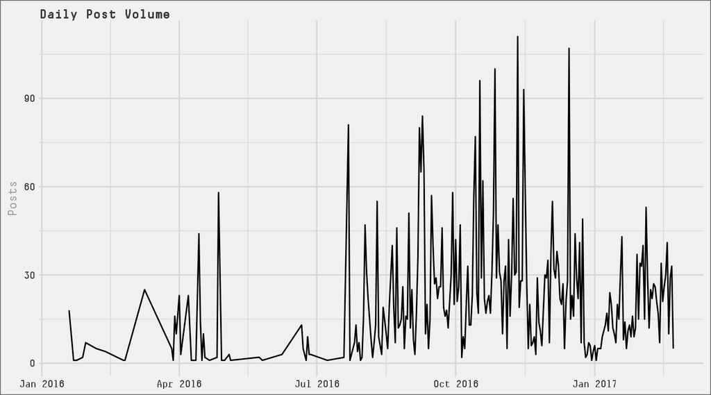

```r
msgs_from_jan %>%
  mutate(day = floor_date(created_at, unit = "day")) %>%
  ggplot(aes(x = day)) +
  geom_line(stat = "count") +
  labs(x = NULL, y = "Posts", title = "Daily Post Volume") +
  theme_jrf(users_v = "rstudio")
```

A more useful way is to view a 7-day rolling count as it takes away from the daily volatily and the sharpness of weekly data.

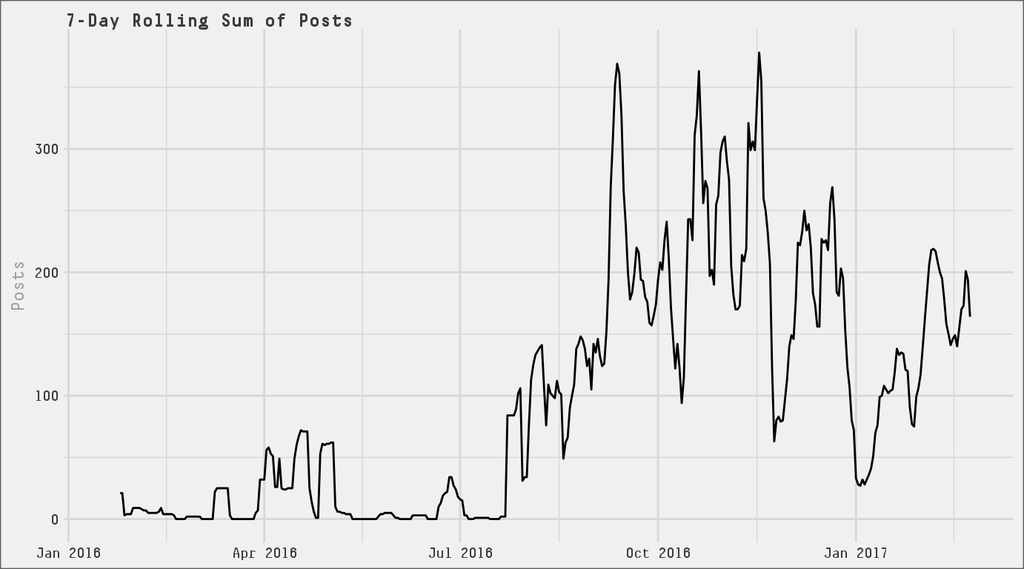

```r
min_day <- floor_date(min(msgs_from_jan$created_at), unit = "day")
max_day <- ceiling_date(max(msgs_from_jan$created_at), unit = "day")

data_frame(day = as_date(seq(from = min_day, to = max_day, by = "day"))) %>%
  left_join(
    msgs_from_jan %>%
      mutate(message_day = as_date(round_date(created_at, unit = "day"))) %>%
      group_by(message_day) %>%
      count()
    , by = c('day'='message_day')
  ) %>%
  mutate(l7_day = roll_sum(n, 7, align = "right", fill = NA, na.rm = TRUE)) %>%
  ggplot(aes(x = day, y = l7_day)) +
  geom_line() +
  labs(x = NULL, y = "Posts", title = "7-Day Rolling Sum of Posts") +
  theme_jrf(users_v = "rstudio")
```

## 4.1 Posts per User

We see that the distribution of post-per users is highly zero-inflated as 223 users have never posted.

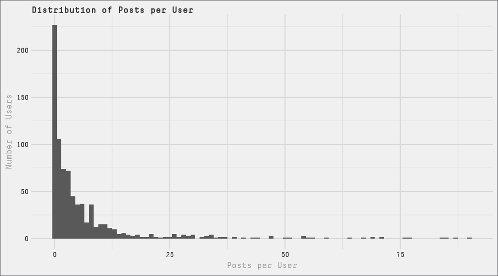

```r
posts_per_user <-
  users %>%
    left_join(
      msgs_from_jan,
      by = c('user_id')
    ) %>%
    group_by(user_id) %>%
    summarise(
      posts = sum(!is.na(msg_id))
    )

posts_per_user %>%
  ggplot(aes(x = posts)) +
  geom_histogram(binwidth = 1) +
  labs(x = "Posts per User", y = "Number of Users", title = "Distribution of Posts per User") +
  theme_jrf(users_v = "rstudio")
```

The median number of posts is 2 and the mean is 6.8 (sd = 12.64). On the right end of the distribution there are some users that post a lot. Below are the top posts by post count:

```r
msgs_from_jan %>%
  left_join(users, by = 'user_id') %>%
  group_by(nickname) %>%
  summarise(posts = n()) %>%
  arrange(desc(posts)) %>%
  head(10) %>%
  pander(caption = "Top Posterss")
```

Top Posterss

| nickname | posts |
| --- | --- |
| Eddie Lee | 90 |
| Vinnie Hung | 87 |
| Angela L | 85 |
| Stephanie Omo-Abu | 84 |
| Neal SenGupta | 77 |
| Roshni Naidu | 76 |
| Antonia Singleton | 71 |
| Michael Finn | 71 |
| Jessica Reichsfeld | 69 |
| Kevin Connors | 69 |

## 4.2 Likes to Posts Metric

Who get’s the most love per post?

```r
users %>%
  left_join(
    msgs_from_jan,
    by = c('user_id')
  ) %>%
  left_join(
    msg_likes %>%
      group_by(msg_id) %>%
      summarise(likes = n())
    , by = 'msg_id'
  ) %>%
  replace_na(list(likes = 0)) %>%
  group_by(user_id, nickname) %>%
  summarise(
    posts = sum(!is.na(msg_id))
    , likes = sum(likes)
  ) %>%
  ungroup() %>%
  mutate(likes_to_post = likes / posts) %>%
  filter(posts > 10) %>%
  arrange(desc(likes_to_post)) %>%
  select(-user_id) %>%
  head(10) %>%
  pander(caption = "Likes per Post (for those with at least 10 posts)")
```

Likes per Post (for those with at least 10 posts)

| nickname | posts | likes | likes_to_post |
| --- | --- | --- | --- |
| Justin Tuck | 15 | 615 | 41.00 |
| Clyde Atkins | 15 | 527 | 35.13 |
| Reid Barnett | 44 | 1048 | 23.82 |
| David Lobo | 21 | 455 | 21.67 |
| Wesley Pritchett | 29 | 561 | 19.34 |
| Steve Rizoli | 27 | 512 | 18.96 |
| Linda Xu | 22 | 417 | 18.95 |
| Neal SenGupta | 77 | 1403 | 18.22 |
| Patrick Feeney | 14 | 255 | 18.21 |
| Jackie Chayet | 11 | 192 | 17.45 |

## 4.3 Time Trends

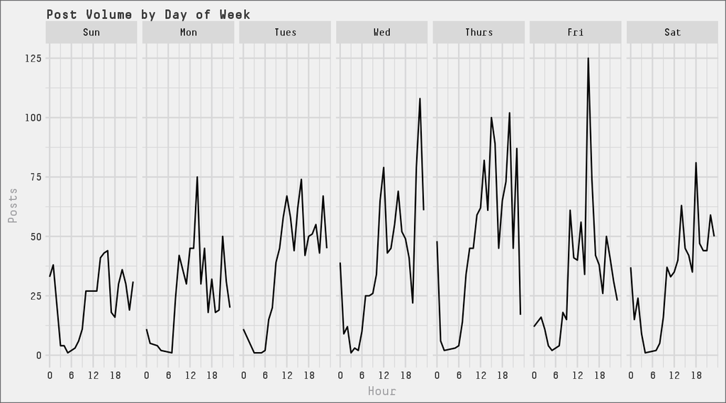

```r
msgs_from_jan %>%
  mutate(
    hour = hour(created_at)
    , day = wday(created_at, label = TRUE)
  ) %>%
  group_by(hour, day) %>%
  count() %>%
  ggplot(aes(hour, y = n)) +
  geom_line(stat = 'identity') +
  facet_grid(.~  day) +
  scale_x_continuous(breaks = c(0, 6, 12, 18)) +
  labs(x = 'Hour', y = 'Posts', title = 'Post Volume by Day of Week') +
  theme_jrf(users_v = 'rstudio')
```

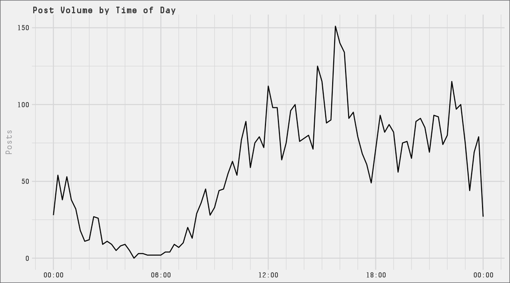

```r
msgs_from_jan %>%
  mutate(created_at = update(created_at, year = 2010, month = 1, day = 1)) %>%
  ggplot(aes(created_at)) +
  geom_freqpoly(binwidth = 60*15) +
  scale_x_datetime(date_minor_breaks = "1 hour",
                   limits = c(ymd_hms("2010-01-01 00:00:00", tz = "America/New_York"),
                              ymd_hms("2010-01-02 00:00:00", tz = "America/New_York")),
                   date_labels = "%H:%M") +
  labs(x = NULL, y = 'Posts', title = 'Post Volume by Time of Day') +
  theme_jrf(users_v = 'rstudio')
```

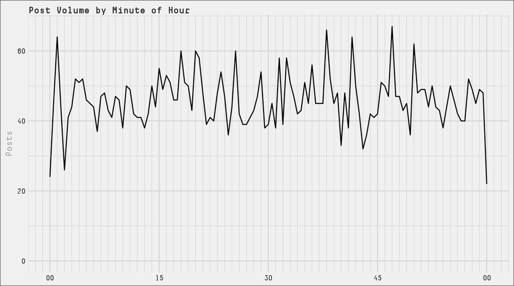

```r
msgs_from_jan %>%
  mutate(created_at = update(created_at, year = 2010, month = 1, day = 1, hour = 0)) %>%
  ggplot(aes(created_at)) +
  geom_freqpoly(binwidth = 30) +
  scale_x_datetime(date_minor_breaks = "1 min",
                   limits = c(ymd_hms("2010-01-01 00:00:00", tz = "America/New_York"),
                              ymd_hms("2010-01-01 01:00:00", tz = "America/New_York")),
                   date_labels = "%M") +
  labs(x = NULL, y = 'Posts', title = 'Post Volume by Minute of Hour') +
  theme_jrf(users_v = 'rstudio')
```

## 4.4 Likes by User

Who gives out the most likes? Neal takes the cake at the moment.

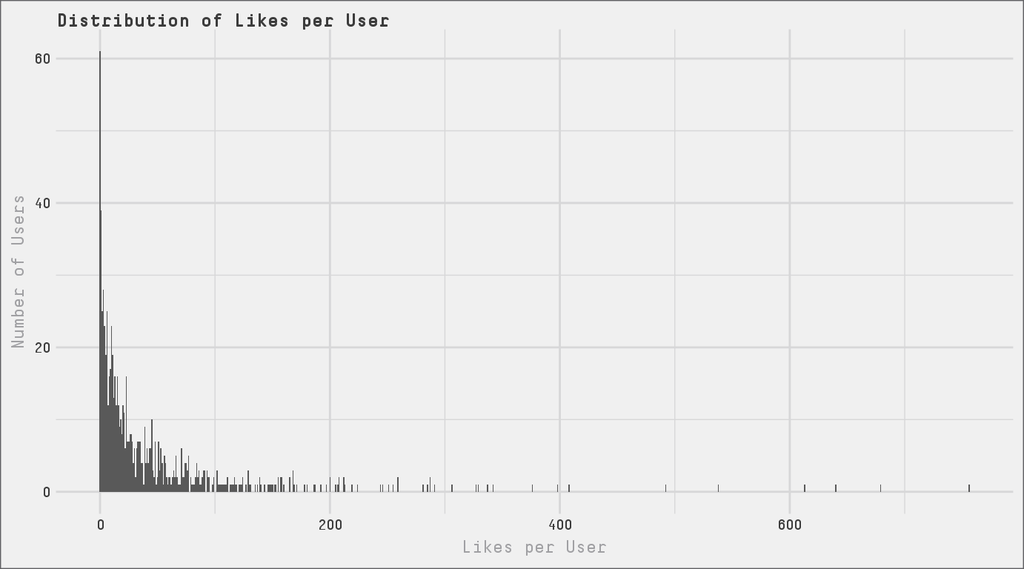

```r
likes_per_user <-
  users %>%
    left_join(
      msg_likes,
      by = c('user_id' = 'liked_by')
    ) %>%
    group_by(user_id, nickname) %>%
    summarise(
      likes = sum(!is.na(msg_id))
    )

likes_per_user %>%
  ggplot(aes(x = likes)) +
  geom_histogram(binwidth = 1) +
  labs(x = "Likes per User", y = "Number of Users", title = "Distribution of Likes per User") +
  theme_jrf(users_v = "rstudio")
```

```r
likes_per_user %>%
  select(-user_id) %>%
  arrange(desc(likes)) %>%
  head(10) %>%
  pander("Top Users by Likes Given")
```

Top Users by Likes Given

| user_id | nickname | likes |
| --- | --- | --- |
| 27838203 | Neal SenGupta | 756 |
| 37533000 | Kern | 679 |
| 5545316 | Shilpa Kumar | 640 |
| 22872726 | Simone Thomas | 613 |
| 4135589 | Dhruv V | 538 |
| 36770140 | Rikhil Bajaj | 492 |
| 27077715 | Roshni Naidu | 408 |
| 233088 | Nibras Islam | 398 |
| 34909846 | Bin Xie | 376 |
| 16368057 | Claire Tramm | 342 |

# 5 Data for MKTG776 Project 1

For the first project in Professor Peter Fader’s *Applied Probability Models in Marketing* (MTKG776), to create count datasets we will focus on messages since August 8, 2016 (the first day of pre-term). Though there was some movement into and out of the group, we will assume that all members of the group at present have been present for the full duration. There are **4** users that posted and have since left the group. These messages (and associated likes, mention, and media) will not be included in the dataset for analysis.

```r
msgs_from_jan %>%
  anti_join(users, by = 'user_id') %>%
  group_by(name) %>%
  summarise(posts = n()) %>%
  arrange(desc(posts)) %>%
  pander(caption = "Users that posted and have since left the group")
```

Users that posted and have since left the group

| name | posts |
| --- | --- |
| Brian Holekamp | 40 |
| Ashley Nagaki | 2 |
| Tom McCarthy | 2 |
| Hope Lewis | 1 |

We create a set of messages that limits to only the time period after August 8, 2016 and removes the users above.

```r
msgs <-
  msgs_from_jan %>%
    inner_join(users %>% select(user_id), by = 'user_id') %>%
    filter(created_at >= "2016-08-08") %>%
    arrange(created_at)
```

| group_id | msg_id | created_at | user_id | name | text |
| --- | --- | --- | --- | --- | --- |
| 19105351 | 147067674863489546 | 2016-08-08 13:19:08 | 15601862 | Sai Rachoor | Looking for two people to share an UberX around 2:10 from 20th and Walnut... |
| 19105351 | 147067797385872966 | 2016-08-08 13:39:33 | 2284828 | Angela L | In @Sai Rachoor |
| 19105351 | 147067798545657618 | 2016-08-08 13:39:45 | 2284828 | Angela L | @Anne Marie Firth Maybe also |
| 19105351 | 147068834886879681 | 2016-08-08 16:32:28 | 2166162 | Stephanie Omo-Abu | Is there a groupme for 1700 Chestnut? |
| 19105351 | 147068898937104305 | 2016-08-08 16:43:09 | 36538156 | Alex Bisson | Any groupme for 1811 chestnut? |
| 19105351 | 147069007922831407 | 2016-08-08 17:01:19 | 6837933 | Charnice | Just added you @Stephanie Omo-Abu |
| 19105351 | 147069211256027618 | 2016-08-08 17:35:12 | 2166162 | Stephanie Omo-Abu | Thx roomie \U0001f60a @Charnice! |
| 19105351 | 147075130512934292 | 2016-08-09 10:01:45 | 5191025 | Oliver Palley | Morning all, completely forgot my jacket at Irish pub last night. Stuffed it into a stool. Blue blazer, half lined, had a cliff bar in the pocket \U0001f44d\U0001f3fc. Wondering if anyone picked it up… |
| 19105351 | 147075340532054927 | 2016-08-09 10:36:45 | 40307921 | Diego Lorenzo | Any groupme for icon? |
| 19105351 | 147076894476931407 | 2016-08-09 14:55:44 | 2166162 | Stephanie Omo-Abu | Going on a Target run if anyone is interested in joining after the sessions! |

Finally, we save each of the files as a single `rda`.

```r
save(users, msgs, msg_likes, msg_media, msg_mentions, file = paste0(data_dir, "groupme_776.rda"))
```